# Applied Computational Methods for Social Sciences

Data Visualization 2: Color, Size, Shape, Transparency, and Linetype

Bogdan G. Popescu

bogdan.popescu@johncabot.edu

John Cabot University

## Learning Outcomes

By the end of this lecture, you will be able to:

- Identify and apply key aesthetics in ggplot2 (color, size, shape, transparency, linetype)
- Distinguish between mapping (data-driven) and setting (fixed) aesthetics
- Enhance plots by layering aesthetics onto common geoms (points, bars, lines, text)
- Evaluate when aesthetics improve clarity vs. when they create clutter

## Simple Geoms

### Aesthetics

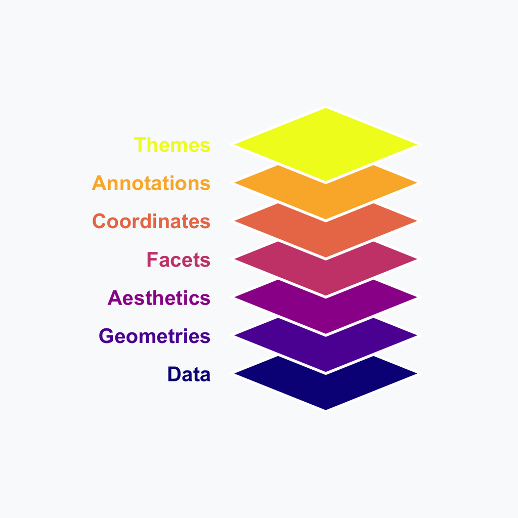

## Simple Geoms

### Aesthetics

- Geoms are the “shapes” your data takes on a graph.

Aesthetics bring plots to life: color, size, shape, transparency, linetype

- `aes()` maps variables to these aesthetics, linking data to visual features.

Aesthetics highlight comparisons and guide attention

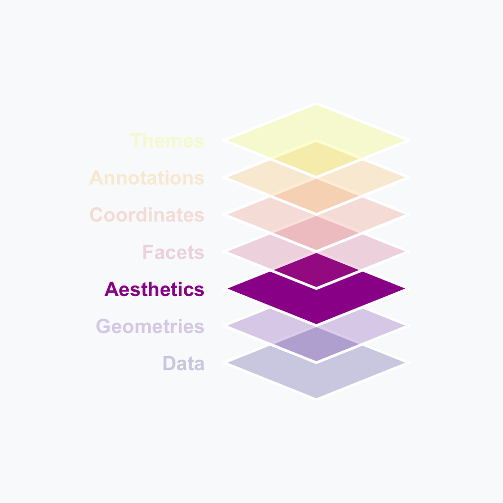

## Simple Geoms

### Examples

These are the simple geoms that we covered previously.

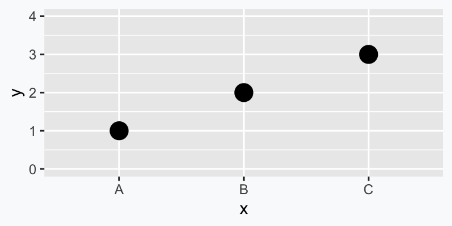

`geom_point`

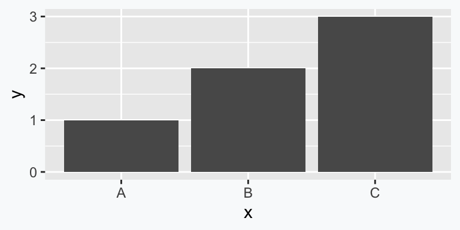

`geom_col`

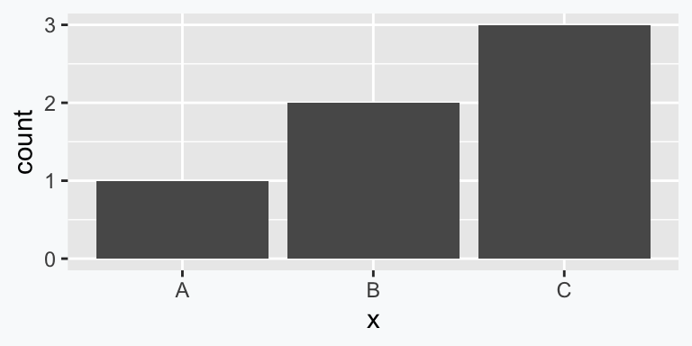

`geom_bar`

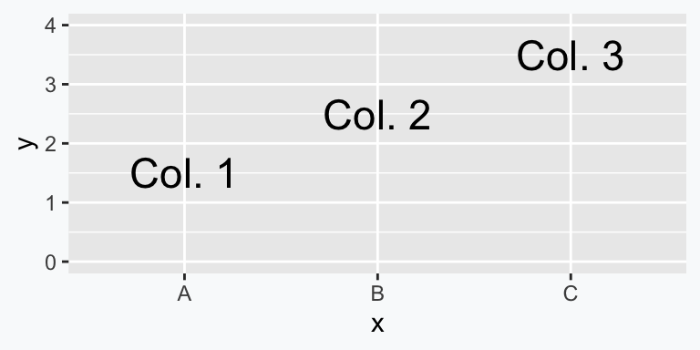

`geom_text`

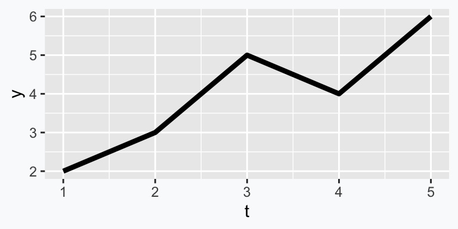

`geom_line`

## Simple Geoms

### Reference

This is what they are used for:

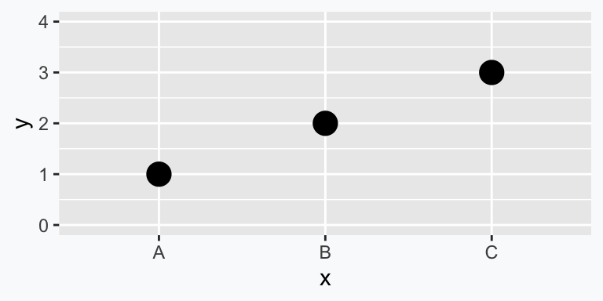

`geom_point`

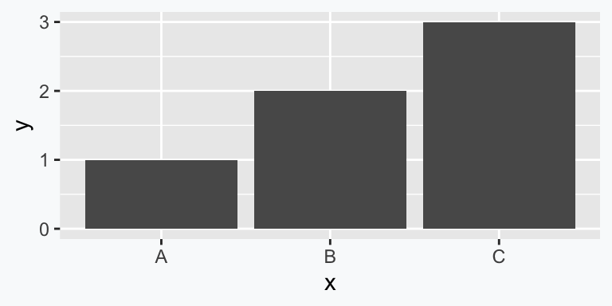

`geom_col`

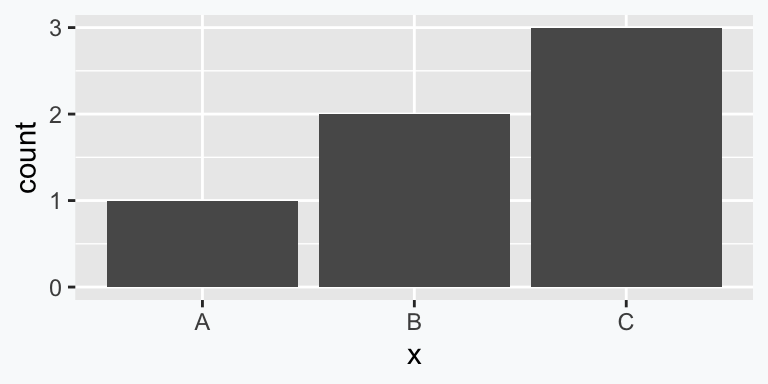

`geom_bar`

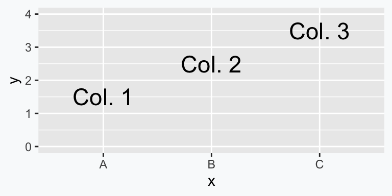

`geom_text`

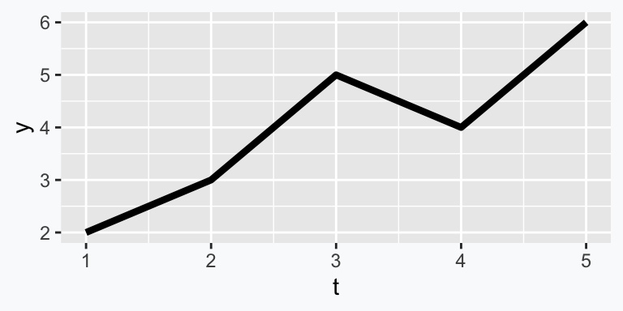

`geom_line`

[output not shown]

# Point Aesthetics

## geom_point

### Aesthetics

Let’s explore how aesthetics change meaning and clarity.

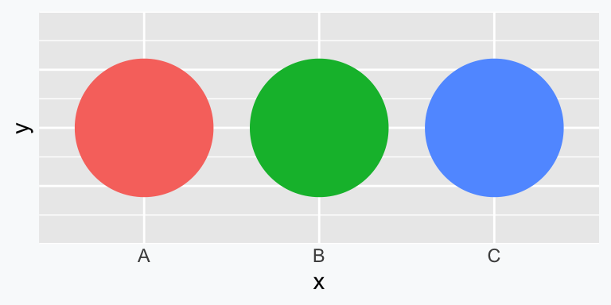

`color`(discrete)

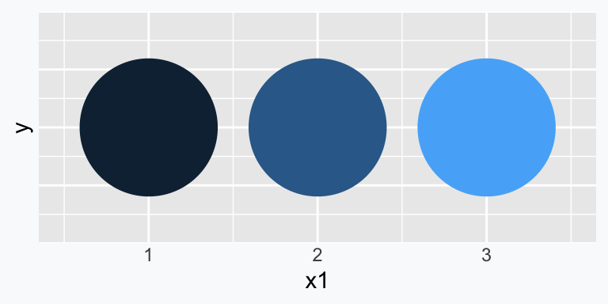

`color`(continuous)

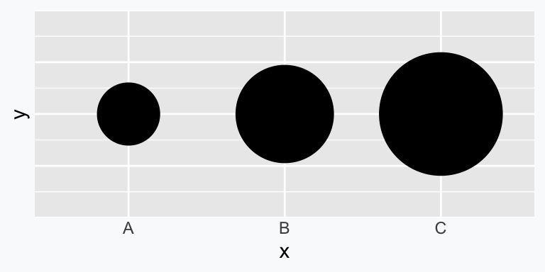

`size`(discrete + continuous)

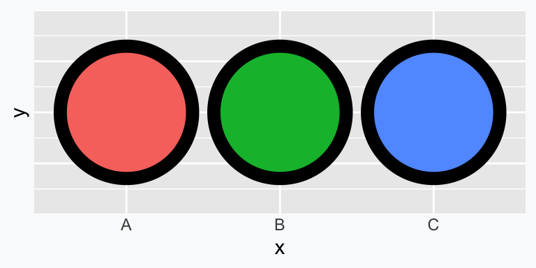

`fill`(discrete + continuous)

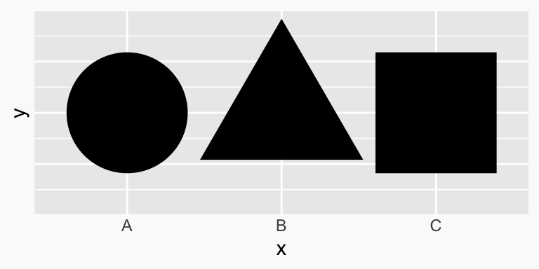

`shape`(discrete)

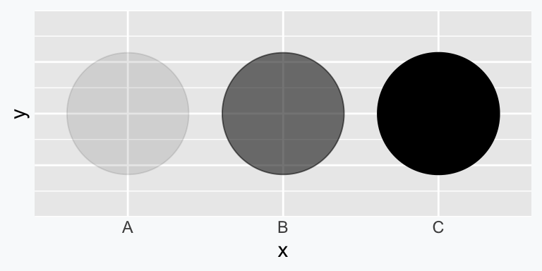

`alpha`(discrete + continuous)

## geom_point

### Aesthetics

This is what they are used for:

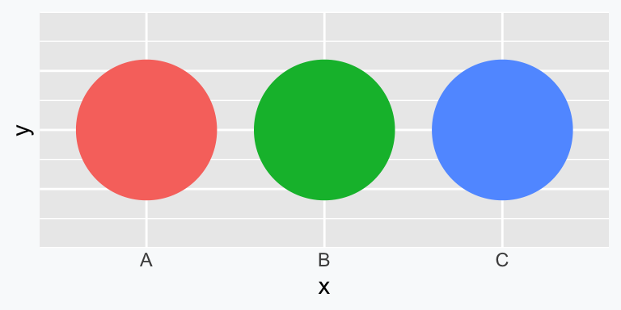

`color`(discrete)

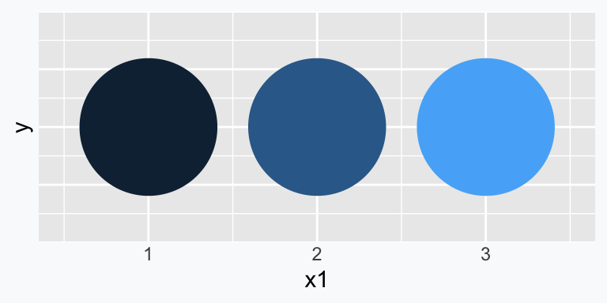

`color`(continuous)

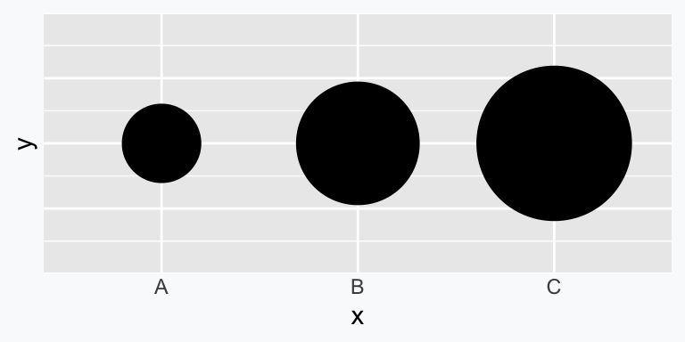

`size`(discrete + continuous)

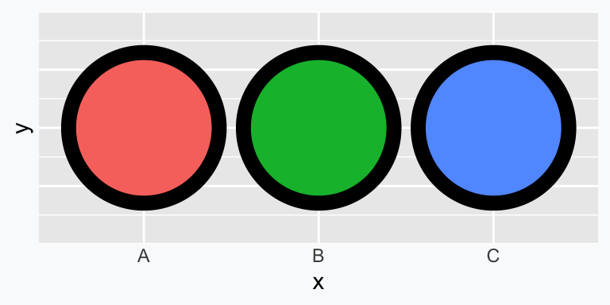

`fill`(discrete + continuous)

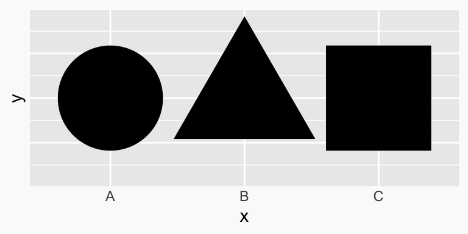

`shape`(discrete)

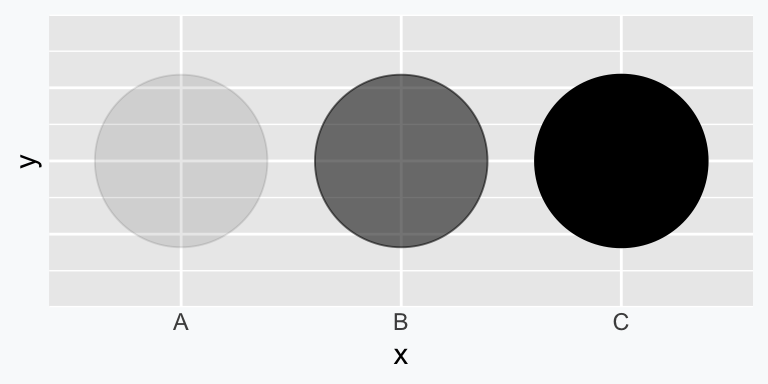

`alpha`(discrete + continuous)

| Aesthetic | Use for |
| --- | --- |
| `color` (discrete) | Differentiate categories with distinct hues |
| `color` (continuous) | Show gradual change or intensity across a numeric scale |
| `size` (discrete + continuous) | Represent magnitude, frequency, or importance; best with moderate differences |
| `fill` (discrete + continuous) | Similar to `color` but applies to filled shapes (bars, areas, points with `pch=21–25`) |
| `shape` (discrete) | Distinguish categories when colors alone aren’t enough; limited shapes available |
| `alpha` (discrete + continuous) | Control transparency to show overlap/density; reduce clutter in crowded plots |

## geom_point

### Simple Geom

Imagine we have data about 9 countries that record their level of democracy from -10 to +10 (x-axis) and their GDP per capita in $1,000s (y-axis).

```r
eg1 <- data.frame(
  democracy = c(-8, -7, -5, -3, 0, 2, 5, 8, 9),   # democracy score
  gdp = c(2, 9, 4, 7, 8, 20, 15, 25, 27)  # GDP per capita in $1,000s
)
```

## geom_point

### Simple Geom

Imagine we have data about 9 countries that record their level of democracy from -10 to +10 (x-axis) and their GDP per capita in $1,000s (y-axis).

| democracy | gdp |
| --- | --- |
| -8 | 2 |
| -7 | 9 |
| -5 | 4 |
| -3 | 7 |
| 0 | 8 |

## geom_point

### Simple Geom

Imagine we have data about 9 countries that record their level of democracy from -10 to +10 (x-axis) and their GDP per capita in $1,000s (y-axis).

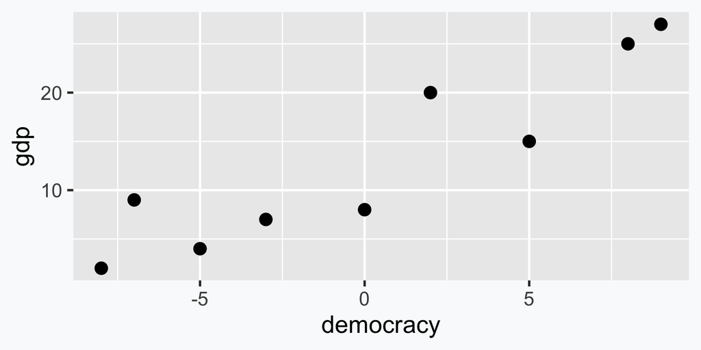

```r
# Scatterplot with geom_point
ggplot(data=eg1,
       aes(x = democracy, y = gdp)) +
  geom_point()
```

## geom_point

### color(discrete)

Imagine we have data about 9 countries that record their level of democracy from -10 to +10 (x-axis) and their GDP per capita in $1,000s (y-axis).

Let’s imagine that we have a new dataset with more variables:

```r
# Reusable dataset
eg1 <- data.frame(
  country = c(
    "North Korea",   # very autocratic, very poor
    "Saudi Arabia",  # autocratic, but richer due to oil
    "Zimbabwe",      # authoritarian, low GDP
    "Russia",        # hybrid regime, middle income
    "Nigeria",       # similar position
    "India",         # low–mid democracy, growing GDP
    "Brazil",        # democracy, mid GDP
    "Poland",        # consolidated democracy, higher GDP
    "South Korea"   # rich democracy
  ),
  democracy = c(-8, -7, -5, -3, 0, 2, 5, 8, 9),          # democracy score
  gdp = c(2, 9, 4, 7, 8, 20, 15, 25, 27),          # GDP per capita ($1,000s)
  region = c("Asia", "Asia", "Africa",
             "Europe", "Africa", "Asia",
             "Americas", "Europe", "Asia"),        # categorical
  population = c(5, 50, 30, 12, 80, 60, 40, 100, 70), # continuous (millions)
  income_group = factor(
    c("Low", "Low", "Low",
      "Middle", "Middle", "Middle",
      "High", "High", "High"),
    levels = c("Low", "Middle", "High")),
  corruption = c(80, 65, 50, 40, 35, 30, 25, 20, 15))
```

## geom_point

### color(discrete)

Imagine we have data about 9 countries that record their level of democracy from -10 to +10 (x-axis) and their GDP per capita in $1,000s (y-axis).

Let’s imagine that we have a new dataset with more variables:

| country | democracy | gdp | region | population | income_group | corruption |
| --- | --- | --- | --- | --- | --- | --- |
| North Korea | -8 | 2 | Asia | 5 | Low | 80 |
| Saudi Arabia | -7 | 9 | Asia | 50 | Low | 65 |
| Zimbabwe | -5 | 4 | Africa | 30 | Low | 50 |
| Russia | -3 | 7 | Europe | 12 | Middle | 40 |
| Nigeria | 0 | 8 | Africa | 80 | Middle | 35 |

## geom_point

### color(discrete)

Imagine we have data about 9 countries that record their level of democracy from -10 to +10 (x-axis) and their GDP per capita in $1,000s (y-axis).

This is how we can emphasize the region (discrete):

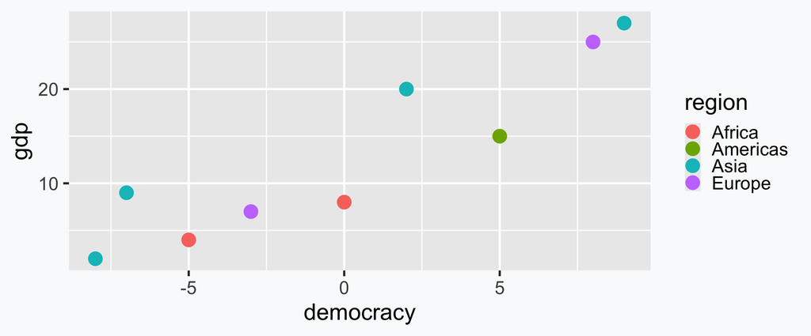

```r
# 1) color (discrete): distinguish categories with distinct hues
ggplot(eg1, aes(x = democracy, y = gdp, color = region)) +
  geom_point()
```

## geom_point

### color(continuous)

Imagine we have data about 9 countries that record their level of democracy from -10 to +10 (x-axis) and their GDP per capita in $1,000s (y-axis).

This is how we can emphasize the corruption levels (continuous):

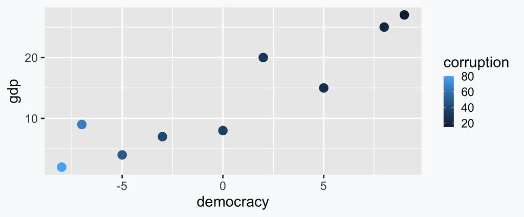

```r
# 2) color (continuous): encode a numeric gradient (low → high)
ggplot(eg1, aes(x = democracy, y = gdp, color = corruption)) +
  geom_point()
```

## geom_point

### size(discrete)

Imagine we have data about 9 countries that record their level of democracy from -10 to +10 (x-axis) and their GDP per capita in $1,000s (y-axis).

This is how we can emphasize the income groups (discrete):

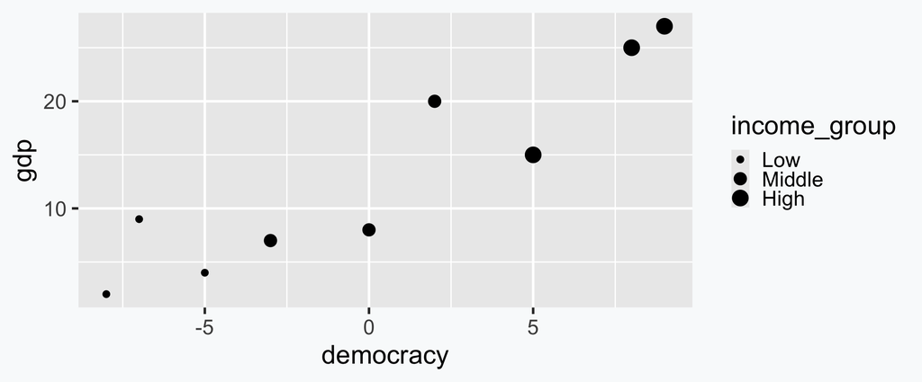

```r
# 3) size (discrete): High income = large points
ggplot(eg1, aes(x = democracy, y = gdp, size = income_group)) +
  geom_point()
```

## geom_point

### size(continuous)

Imagine we have data about 9 countries that record their level of democracy from -10 to +10 (x-axis) and their GDP per capita in $1,000s (y-axis).

This is how we can emphasize population size (continuous)

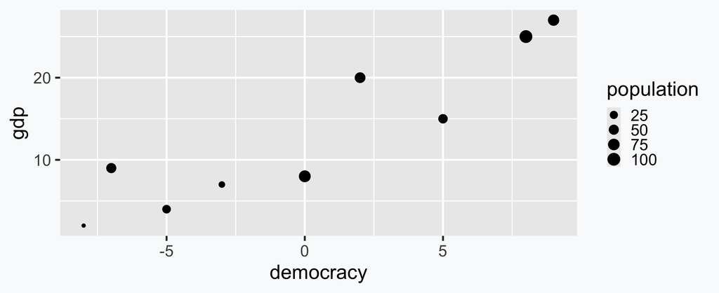

```r
# 4) size (continuous): encode magnitude (e.g., population)
ggplot(eg1, aes(x = democracy, y = gdp, size = population)) +
  geom_point()
```

## geom_point

### fill(discrete)

Imagine we have data about 9 countries that record their level of democracy from -10 to +10 (x-axis) and their GDP per capita in $1,000s (y-axis).

This is how we can emphasize income groups (discrete).

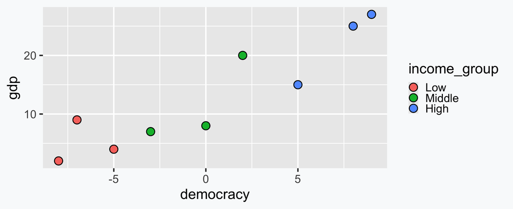

```r
# 5) fill (discrete): categories on filled shapes (pch 21–25, bars, areas)
ggplot(eg1, aes(x = democracy, y = gdp, fill = income_group)) +
  geom_point(shape = 21, color = "black")
```

## geom_point

### fill(continuous)

Imagine we have data about 9 countries that record their level of democracy from -10 to +10 (x-axis) and their GDP per capita in $1,000s (y-axis).

This is how we can emphasize the level of corruption (continuous).

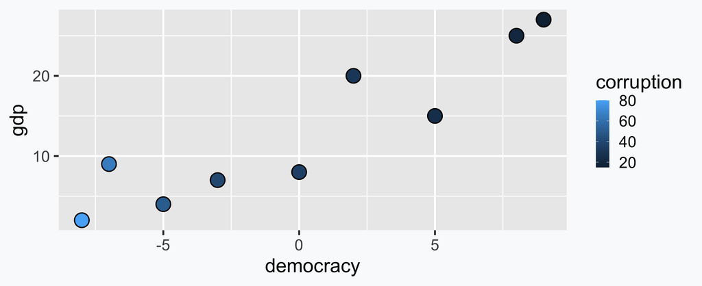

```r
# 6) fill (continuous): numeric gradient on filled shapes
ggplot(eg1, aes(x = democracy, y = gdp, fill = corruption)) +
  geom_point(shape = 21, color = "black")
```

## geom_point

### shape(discrete)

Imagine we have data about 9 countries that record their level of democracy from -10 to +10 (x-axis) and their GDP per capita in $1,000s (y-axis).

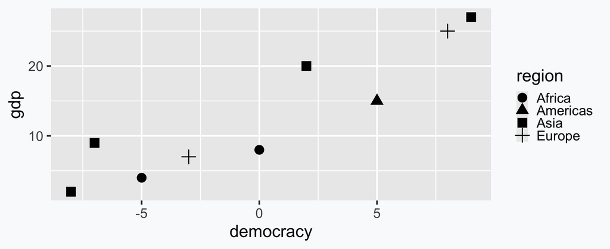

```r
# 7) shape (discrete): differentiate categories; limited distinct shapes
ggplot(eg1, aes(x = democracy, y = gdp, shape = region)) +
  geom_point()
```